# ST558 Project2

Shan Luo, Chengxi Zhou

2022-07-03

```r
rmarkdown::render("ST558_Project2_Group10.Rmd", output_file = "lifestyle.html", params = list(Channels = 'data_channel_is_lifestyle'))
```

```r
News <- read_csv("OnlineNewsPopularity.csv", show_col_types = FALSE)
News <- News %>%
  filter(!!rlang::sym(params$Channels) == 1) %>%
  select(shares, n_tokens_content, num_imgs, num_videos,
         global_rate_positive_words, global_subjectivity, is_weekend)
News$is_weekend <- factor(News$is_weekend)
```

```r
cor(select(News ,shares, n_tokens_content, num_imgs, num_videos,
           global_rate_positive_words, global_subjectivity))
```

```
##                                  shares n_tokens_content    num_imgs
## shares                      1.000000000       0.07302425  0.05120130
## n_tokens_content            0.073024252       1.00000000  0.46442622
## num_imgs                    0.051201300       0.46442622  1.00000000
## num_videos                  0.088311059       0.04005714 -0.05500975
## global_rate_positive_words -0.005395787       0.12779576  0.06914830
## global_subjectivity         0.017739883       0.09117454  0.19925466
##                               num_videos global_rate_positive_words
## shares                      0.0883110588              -0.0053957870
## n_tokens_content            0.0400571423               0.1277957592
## num_imgs                   -0.0550097529               0.0691482967
## num_videos                  1.0000000000              -0.0000483498
## global_rate_positive_words -0.0000483498               1.0000000000
## global_subjectivity         0.0254110044               0.3833653985
##                            global_subjectivity
## shares                              0.01773988
## n_tokens_content                    0.09117454
## num_imgs                            0.19925466
## num_videos                          0.02541100
## global_rate_positive_words          0.38336540
## global_subjectivity                 1.00000000
```

```r
set.seed(1)
trainIndex <- createDataPartition(News$shares, p = 0.7, list = FALSE)
train <- News[trainIndex, ]
test <- News[-trainIndex, ]
```

# EDA

## Numeric Summary Table

```r
apply(X = select(train, shares:global_subjectivity), MARGIN = 2,
      FUN = function(x) {
        summaries <- c(min(x), mean(x), median(x), max(x), sd(x), IQR(x))
        names(summaries) <- c("Min", "Mean", "Median", "Max", "Sd", "IQR")
        summaries
      })
```

```
##            shares n_tokens_content   num_imgs num_videos
## Min        28.000           0.0000   0.000000  0.0000000
## Mean     3535.421         634.7976   4.934783  0.4429348
## Median   1700.000         508.5000   1.000000  0.0000000
## Max    196700.000        8474.0000 111.000000 15.0000000
## Sd       8131.063         597.1858   8.281820  1.3419971
## IQR      2125.000         489.2500   7.000000  0.0000000
##        global_rate_positive_words global_subjectivity
## Min                    0.00000000          0.00000000
## Mean                   0.04470561          0.47396401
## Median                 0.04432815          0.47787444
## Max                    0.12138728          0.77777778
## Sd                     0.01517567          0.09191057
## IQR                    0.01870835          0.10199113
```

From numeric summary table, if one variable’s mean is greater than median, it has a right skewed distribution. If the mean is less than median, it has a left skewed distribution. If mean is close to median, it may have a symmetric distribution. If the standard deviation is unusual, there may be some outliers.

## Contingency Table

```r
table(train$is_weekend)
```

```
##
##    0    1
## 1186  286
```

From the contingency table, we can see how many articles are published on weekday and weekend.

## Bar Plot

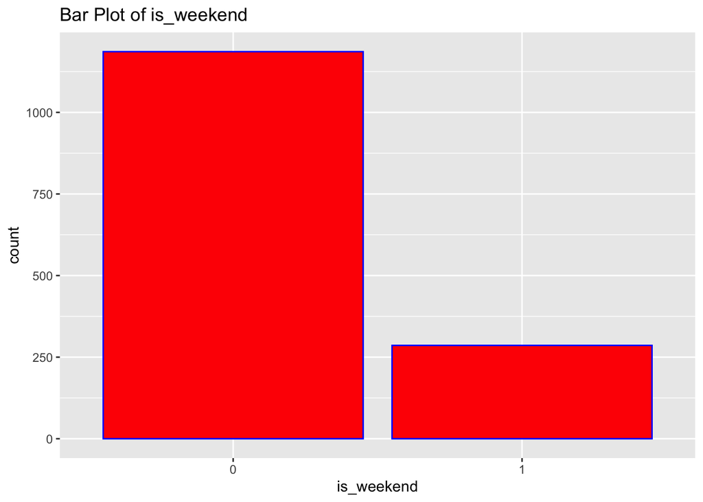

```r
g <- ggplot(data = train, aes(x = is_weekend))
g + geom_bar(fill = "Red", color = "Blue") +
  labs(title = "Bar Plot of is_weekend")
```

From the bar plot, we can see how many articles are published on weekday and weekend and visualize the difference.

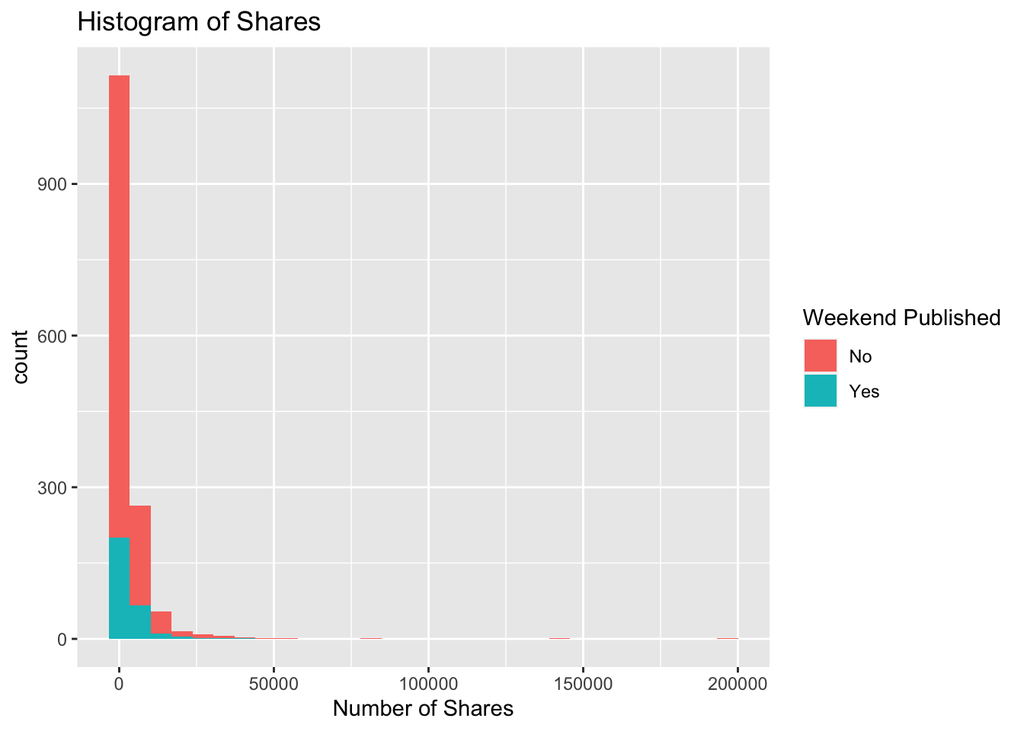

```r
g <- ggplot(data = train, aes(x = shares))
g + geom_histogram(bins = 30, aes(fill = is_weekend)) +
  labs(x = "Number of Shares",
       title = "Histogram of Shares") +
  scale_fill_discrete(name = "Weekend Published", labels = c("No", "Yes"))
```

For histogram, we can see the distribution of the number of shares. If we have majority of count on the left side and less count on right side, it may have a right skewed distribution. It indicates that most of articles have small number of shares. If we have majority of count on the right side and less count on left side, it may have a left skewed distribution. It indicates that most of articles have large number of shares. If we see a bell shape, it may have a symmetric distribution. It indicating most of articles have relatively large shares.

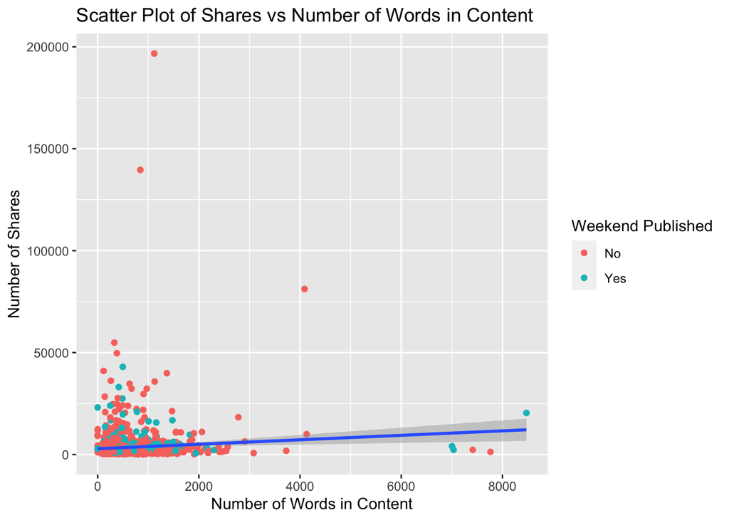

```r
g <- ggplot(data = train, aes(x = n_tokens_content, y = shares))
g + geom_point(aes(color = is_weekend)) +
  geom_smooth(method = "lm") +
  labs(x = "Number of Words in Content",
       y = "Number of Shares",
       title = "Scatter Plot of Shares vs Number of Words in Content") +
  scale_color_discrete(name = "Weekend Published", labels = c("No", "Yes"))
```

We can inspect the trend of shares as a function of the number of words in content. If the points show an upward trend, then articles with more number of words in the content to be shared more often. If we see a negative trend then articles with more number of words in the content tend to be shared less often.

# Modeling

## Baisc Idea of Linear Regression

Regression models allow easy prediction of response and inference. Linear regression is that we model a response as a linear function of some predictors. Model fit by minimizing the sum of squared residuals.

```r
# Fit linear model
mod <- lm(shares ~ (n_tokens_content + num_imgs + num_videos +
                      global_rate_positive_words + global_subjectivity +
                      is_weekend)^2 ,data =  train)
# Use forward selection to  choose model
forward_mod <- step(mod, direction = "forward")
```

```
## Start:  AIC=26400.8
## shares ~ (n_tokens_content + num_imgs + num_videos + global_rate_positive_words +
##     global_subjectivity + is_weekend)^2
```

```r
fit <- train(shares ~ (n_tokens_content + num_imgs + num_videos +
                         global_rate_positive_words + global_subjectivity +
                         is_weekend)^2,
             data = train,
             method = "lm",
             preProcess = c("center", "scale"),
             trControl = trainControl(method = "cv", number = 5))
fit
```

```
## Linear Regression
##
## 1472 samples
##    6 predictor
##
## Pre-processing: centered (21), scaled (21)
## Resampling: Cross-Validated (5 fold)
## Summary of sample sizes: 1179, 1177, 1176, 1177, 1179
## Resampling results:
##
##   RMSE      Rsquared     MAE
##   8274.591  0.003626336  3323.125
##
## Tuning parameter 'intercept' was held constant at a value of TRUE
```

```r
pred <- predict(fit, newdata = test)
postResample(pred, test$shares)
```

```
##         RMSE     Rsquared          MAE
## 1.121763e+04 2.466283e-04 3.851382e+03
```

## Random Forest

Since the response is continuous, we choose to use regression tree.

The bootstrapping is that we resample from data or a fitted model and apply method or estimation to each resample. We see how the model or method behave.

For Bootstrap Aggregation(Bagged) for regression tree, we create a bootstrap sample, train tree on the sample, repeat B = 1000 times, and average over these predictions as final prediction.

```r
RFfit <- train(shares ~ n_tokens_content + num_imgs + num_videos,
               data = train,
               method = "rf",
               trControl = trainControl(method = "cv", number = 5),
               preProcess = c("center", "scale"),
               tuneGrid = data.frame(mtry = 1:6))
RFfit
```

```
## Random Forest
##
## 1472 samples
##    3 predictor
##
## Pre-processing: centered (3), scaled (3)
## Resampling: Cross-Validated (5 fold)
## Summary of sample sizes: 1177, 1178, 1178, 1177, 1178
## Resampling results across tuning parameters:
##
##   mtry  RMSE      Rsquared    MAE
##   1     7642.578  0.00929634  3054.482
##   2     7919.256  0.01327019  3191.210
##   3     7996.212  0.01590409  3274.578
##   4     8051.731  0.01441516  3281.406
##   5     8008.215  0.01581281  3268.976
##   6     8011.792  0.01467469  3278.124
##
## RMSE was used to select the optimal model using the smallest value.
## The final value used for the model was mtry = 1.
```

```r
RFpred <- predict(RFfit, newdata = test)
postResample(RFpred, test$shares)
```

```
##         RMSE     Rsquared          MAE
## 1.174535e+04 4.789381e-04 3.813262e+03
```